# Calculating the genomic relationship matrice with all gene pools

Juliette Archambeau

14 novembre, 2020

In this report, we used `piMASS` outputs. `piMASS` (Posterior inference using Model Averaging and Subset Selection) is a software on [Stephens lab website](https://stephenslab.uchicago.edu/software.html#pimass). `piMASS` is written and maintained by Yongtao Guan, implements MCMC-based inference methods for Bayesian variable-selection regression described in Guan and Stephens (2011).

GRM = Genomic relationship matrix = kinship matrix with relationship between individuals estimated using genomic markers.

We calculate first a GRM with all SNPs and then a GRM with SNPs considered as "neutral" according to the `piMASS` ouputs. In the manuscript, we use the GRM based only on "neutral" SNPs.

# 1 A GRM with all SNPs

In this first section, we calculate a genomic relationship matrix with all the SNPs.

## 1.1 Data

### 1.1.1 Load and format genotype file

**Comment**: Not in R, I used the "find and replace" function of *Mousepad* to replace `?` by `NA` in the file `5165snps523genotypes.txt`. There were 17263 substitutions. After these changes, the new file was called "5165snps523genotypesNA.txt".

Then, in R, here are the different steps to format data:

- load files with the genotype names and the genotype of each clone for each SNP
- remove columns of no interest
- reassign to each genotype its name using another file (`geno_names`).

```r
# File with the genotype names (clone names)
geno_names <- read.delim2("../../data/ClonapinBlups523IndPiMASSJuly2019.txt", row.names=1)

# File with the genotype of each clone for each SNP
geno <- read.csv("../../data/5165snps523genotypesNA.txt", header=FALSE, row.names=1)
str(geno[,1:8])
```

```
## 'data.frame':    5165 obs. of  8 variables:
##  $ V2: Factor w/ 4 levels "A","C","G","T": 4 4 2 3 4 3 1 3 4 3 ...
##  $ V3: Factor w/ 4 levels "A","C","G","T": 1 2 4 1 1 1 4 1 3 2 ...
##  $ V4: int  1 1 2 1 0 0 1 0 1 0 ...
##  $ V5: int  0 1 2 1 0 2 1 0 1 0 ...
##  $ V6: int  0 0 1 0 1 1 2 0 0 0 ...
##  $ V7: int  0 0 0 2 1 2 2 0 0 0 ...
##  $ V8: int  0 2 1 0 1 1 2 0 0 0 ...
##  $ V9: int  2 1 0 1 0 1 2 0 0 0 ...
```

```r
dim(geno) # SNPs in rows, genotypes in columns
```

```
## [1] 5165  525
```

```r
# In this file, SNPs have their names, but not the genotypes.
head(geno[,1:10])
```

```
##          V2 V3 V4 V5 V6 V7 V8 V9 V10 V11
## SNP_0001  T  A  1  0  0  0  0  2   0   0
## SNP_0002  T  C  1  1  0  0  2  1   1   1
## SNP_0003  C  T  2  2  1  0  1  0   2   1
## SNP_0004  G  A  1  1  0  2  0  1   0   0
## SNP_0005  T  A  0  0  1  1  1  0   0   0
## SNP_0006  G  A  0  2  1  2  1  1   1   2
```

```r
# Removing the first two columns with allele info (A,T, G or C)
geno <- geno[,3:dim(geno)[[2]]]

# genotype name for each column
colnames(geno) <- rownames(geno_names)

rm(geno_names)

head(geno[,1:10])
```

```
##          ALT1 ALT10 ALT2 ALT3 ALT4 ALT5 ALT6 ALT8 ALT9 ARM1
## SNP_0001    1     0    0    0    0    2    0    0    0    0
## SNP_0002    1     1    0    0    2    1    1    1    2    2
## SNP_0003    2     2    1    0    1    0    2    1    1    1
## SNP_0004    1     1    0    2    0    1    0    0    1    0
## SNP_0005    0     0    1    1    1    0    0    0    0    0
## SNP_0006    0     2    1    2    1    1    1    2    2    1
```

### 1.1.2 Looking at NAs

```r
sum(is.na(geno))
```

```
## [1] 17263
```

```r
sapply(geno, function(x) sum(is.na(x)))
```

[output not shown]

[output cut: 8 more lines]

**How many NAs per genotype? (=per column)**

```r
column_nas <- sapply(geno, function(x) sum(is.na(x)))

# All genotypes have several SNPs with missing values
length(column_nas[column_nas>0])
```

```
## [1] 523
```

```r
# Range and mean of the number of missing values for each genotype:
range(column_nas)
```

```
## [1]    7 1038
```

```r
mean(column_nas)
```

```
## [1] 33.00765
```

**How many NAs per SNP? (=per row)**

```r
rows_nas <- apply(geno,1,function (x) sum (is.na (x)))

# Range of the number of missing values for each SNP:
range(rows_nas)
```

```
## [1]   0 142
```

```r
# Mean number of missing values for each SNP
mean(rows_nas)
```

```
## [1] 3.342304
```

```r
# Number of SNPs with at least one missing value
length(rows_nas[rows_nas>0])
```

```
## [1] 3366
```

```r
# Number of SNPs with at least 2 missing values
length(rows_nas[rows_nas>1])
```

```
## [1] 2278
```

**Histograms of NAs per genotype and per SNP**

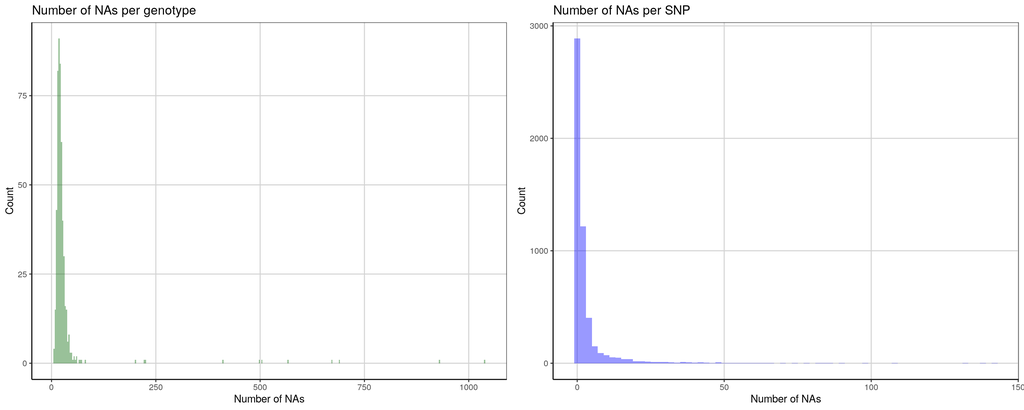

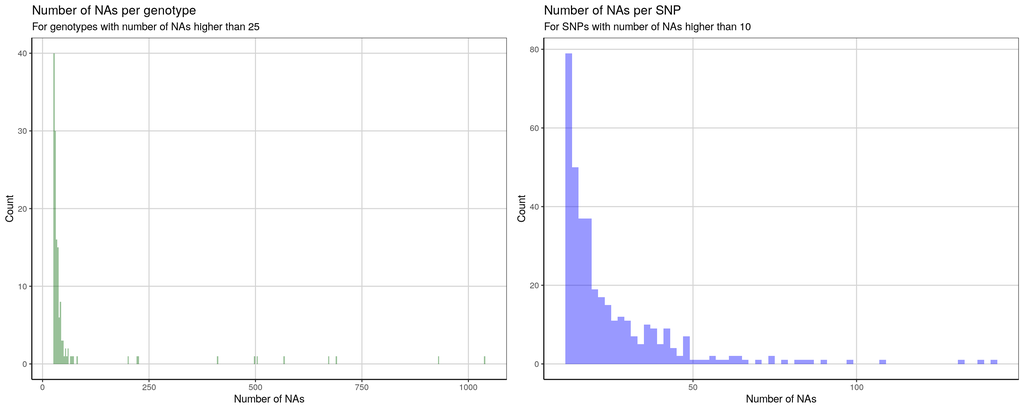

### 1.1.3 Checking major/minor alleles for each SNP

Here, I just wanted to check that for a given genotype (clone):

- SNPs coded with `0` were homozygotes for the major allele.
- SNPs coded with `1` were heterozygotes.
- SNPs coded with `2` were homozygotes for the minor alleles

This is not the case for three SNPs that have more homozygotes for the minor alleles than for the major allele. I don't think that this is a problem to compute the GRM matrix, because even if the SNPs have to be ordered with `0`,`1` and `2`, `2` does not necessarily have to be the homozygotes of the minor allele (and `0` the homozygotes of the major allele). Santiago Gonzalez-Martinez also said that there was no prolem here.

```r
# Number of 0 for each SNP
zero <- apply(geno,1,function(x) sum(x==0,na.rm = T))
mean(zero)
```

```
## [1] 307.376
```

```r
# Number of 2 for each SNP
two <- apply(geno,1,function(x) sum(x==2,na.rm = T))
mean(two)
```

```
## [1] 54.91694
```

```r
# Number of 1 for each SNP
one <- apply(geno,1,function(x) sum(x==1,na.rm = T))
mean(one)
```

```
## [1] 157.3648
```

```r
# Number of NAs for each SNP
nas <- apply(geno,1,function(x) sum(is.na(x)))
mean(nas)
```

```
## [1] 3.342304
```

```r
# SNPs which have more 2 than 0
which((2 * zero + one ) - (2*two + one)<0)
```

```
## SNP_0827 SNP_1492 SNP_2326
##      655     1184     1877
```

```r
df <- data.frame(SNP_0827=c(sum(geno["SNP_0827",]==0,na.rm=T),sum(geno["SNP_0827",]==1,na.rm=T),sum(geno["SNP_0827",]==2,na.rm=T),sum(is.na(geno["SNP_0827",]))),
                 SNP_1492=c(sum(geno["SNP_1492",]==0,na.rm=T),sum(geno["SNP_1492",]==1,na.rm=T),sum(geno["SNP_1492",]==2,na.rm=T),sum(is.na(geno["SNP_1492",]))),
                 SNP_2326=c(sum(geno["SNP_2326",]==0,na.rm=T),sum(geno["SNP_2326",]==1,na.rm=T),sum(geno["SNP_2326",]==2,na.rm=T),sum(is.na(geno["SNP_2326",]))))
row.names(df) <- c("Nbzero","Nbone","Nbtwo","Nbnas")
df
```

```
##        SNP_0827 SNP_1492 SNP_2326
## Nbzero      131      147      141
## Nbone       211      226      237
## Nbtwo       133      148      143
## Nbnas        48        2        2
```

## 1.2 Calculating the GRM

```r
# replacing integers by numeric values
str(geno[,1:5])
```

```
## 'data.frame':    5165 obs. of  5 variables:
##  $ ALT1 : int  1 1 2 1 0 0 1 0 1 0 ...
##  $ ALT10: int  0 1 2 1 0 2 1 0 1 0 ...
##  $ ALT2 : int  0 0 1 0 1 1 2 0 0 0 ...
##  $ ALT3 : int  0 0 0 2 1 2 2 0 0 0 ...
##  $ ALT4 : int  0 2 1 0 1 1 2 0 0 0 ...
```

```r
geno[,1:dim(geno)[[2]]] <- apply(geno[ , 1:dim(geno)[[2]]], 2, function(x) as.numeric(as.character(x)))
str(geno[,1:5])
```

```
## 'data.frame':    5165 obs. of  5 variables:
##  $ ALT1 : num  1 1 2 1 0 0 1 0 1 0 ...
##  $ ALT10: num  0 1 2 1 0 2 1 0 1 0 ...
##  $ ALT2 : num  0 0 1 0 1 1 2 0 0 0 ...
##  $ ALT3 : num  0 0 0 2 1 2 2 0 0 0 ...
##  $ ALT4 : num  0 2 1 0 1 1 2 0 0 0 ...
```

```r
mat <- as.matrix(geno)
mat <- t(as.matrix(geno))
str(mat)
```

```
##  num [1:523, 1:5165] 1 0 0 0 0 2 0 0 0 0 ...
##  - attr(*, "dimnames")=List of 2
##   ..$ : chr [1:523] "ALT1" "ALT10" "ALT2" "ALT3" ...
##   ..$ : chr [1:5165] "SNP_0001" "SNP_0002" "SNP_0003" "SNP_0004" ...
```

```r
# Snps in colums and genotypes in rows
dim(mat)
```

```
## [1]  523 5165
```

```r
mat[1:5,1:5]
```

```
##       SNP_0001 SNP_0002 SNP_0003 SNP_0004 SNP_0005
## ALT1         1        1        2        1        0
## ALT10        0        1        2        1        0
## ALT2         0        0        1        0        1
## ALT3         0        0        0        2        1
## ALT4         0        2        1        0        1
```

### 1.2.1 package `AGHmatrix`

> Different ways to compute the matrix

**a) A matrix with:**

- VanRaden method (`method`)
- no threshold for minor allele frequencies (`maf`)
- no threshold for missing values (`thresh.missing`)
- no imputation of missing values (`impute`)

```r
Gmat.all.a <- Gmatrix(mat,method="VanRaden", missingValue=NA,verify.posdef=T,maf=0,thresh.missing = 1,impute.method = FALSE)
```

```
## Initial data:
##  Number of Individuals: 523
##  Number of Markers: 5165
##
## Missing data check:
##  Total SNPs: 5165
##   0 SNPs dropped due to missing data threshold of 1
##  Total of: 5165  SNPs
## MAF check:
##  No SNPs with MAF below 0
## Monomorphic check:
##  No monomorphic SNPs
## Summary check:
##  Initial:  5165 SNPs
##  Final:  5165  SNPs ( 0  SNPs removed)
##
##   Matrix is NOT positive definite. It has  1  eigenvalues <= 0
##
## Completed! Time = 1.167  seconds
```

```r
is.symmetric.matrix(Gmat.all.a)
```

```
## [1] FALSE
```

```r
sum(eigen(Gmat.all.a)$values<0)
```

```
## [1] 1
```

This matrix is not symetric and with 1 negative eigen value.

**b) A matrix with:**

- VanRaden method (`method`)
- no threshold for minor allele frequencies (`maf`)
- no threshold for missing values (`thresh.missing`)
- missing values are imputed with the "mean" (`impute`)

```r
# A matrix with the max of missing data accepted to each marker = 0
Gmat.all.b <- Gmatrix(mat,method="VanRaden", missingValue=NA,verify.posdef=T,maf=0,thresh.missing = 1,impute.method = "mean")
```

```
## Initial data:
##  Number of Individuals: 523
##  Number of Markers: 5165
##
## Missing data check:
##  Total SNPs: 5165
##   0 SNPs dropped due to missing data threshold of 1
##  Total of: 5165  SNPs
## MAF check:
##  No SNPs with MAF below 0
## Monomorphic check:
##  No monomorphic SNPs
## Summary check:
##  Initial:  5165 SNPs
##  Final:  5165  SNPs ( 0  SNPs removed)
##
## Completed! Time = 1.119  seconds
```

```r
is.symmetric.matrix(Gmat.all.b)
```

```
## [1] FALSE
```

```r
sum(eigen(Gmat.all.b)$values<0)
```

```
## [1] 0
```

The matrix is not symetric but doesn't have negative eigen values.

**c) A matrix with:**

- Yang method (`method`)
- no threshold for minor allele frequencies (`maf`)
- no threshold for missing values (`thresh.missing`)
- no imputation of missing values (`impute`)

```r
# A matrix with the max of missing data accepted to each marker = 0
Gmat.all.c <- Gmatrix(mat,method="Yang", missingValue=NA,verify.posdef=T,maf=0,thresh.missing = 1,impute.method = FALSE)
```

```
## Initial data:
##  Number of Individuals: 523
##  Number of Markers: 5165
##
## Missing data check:
##  Total SNPs: 5165
##   0 SNPs dropped due to missing data threshold of 1
##  Total of: 5165  SNPs
## MAF check:
##  No SNPs with MAF below 0
## Monomorphic check:
##  No monomorphic SNPs
## Summary check:
##  Initial:  5165 SNPs
##  Final:  5165  SNPs ( 0  SNPs removed)
##
##   Matrix is NOT positive definite. It has  6  eigenvalues <= 0
##
## Completed! Time = 1.31  seconds
```

```r
is.symmetric.matrix(Gmat.all.c)
```

```
## [1] FALSE
```

```r
sum(eigen(Gmat.all.c)$values<0)
```

```
## [1] 6
```

This matrix is not symetric and with 6 negative eigen values.

**Looking at differences between matrices:**

```r
all.equal(Gmat.all.a,Gmat.all.b)
```

```
## [1] "Mean relative difference: 0.01665923"
```

```r
all.equal(Gmat.all.a,Gmat.all.c)
```

```
## [1] "Mean relative difference: 0.1218208"
```

```r
all.equal(Gmat.all.c,Gmat.all.b)
```

```
## [1] "Mean relative difference: 0.1357612"
```

```r
heatmap(Gmat.all.a)
heatmap(Gmat.all.b)
heatmap(Gmat.all.c)
```

[output not shown]

> Questions for Santi!

**Comments about hte choice of the parameters to calculate the GRM:**

- Method of VanRaden or Yang? (`method`)

Santiago Gonzalez-Martinez: "I prefer VanRaden, but not strong feelings here."

- Which threshold for minor allele frequencies (`maf`)? (Until now, I fixed a threshold of 0 for minor allele frequencies)

Santiago Gonzalez-Martinez: "It is better not to filter by MAF, as rare alleles contain also family information."

- Do I need to fix a threshold on missing data (using = `thresh.missing`) ? (SNPs below this frequency value will be maintained. If `thresh.missing` equal to 1, no threshold and imputation is considered.

Santiago Gonzalez-Martinez: "I think the amount of missing data is acceptable, so better not to filter by missing data."

- Which imputation method? `impute.method`: FALSE to not impute missing data, "mean" to impute the missing data by the mean, "mode" to impute the missing data my the mode.

Santiago Gonzalez-Martinez: "In this case it is truly better not to impute, unless you do some imputation by gene pool separately, as adding the mean or mode genotype would dilute artificially the population structure."

### 1.2.2 package `synbreed`

`synbreed` need alleles to be coded with "AA", "AB" and "BB" (or "A/T","G/C"...).

```r
mat.syn <- mat
mat.syn[mat.syn ==1] <- "AB"
mat.syn[mat.syn ==2] <- "BB"
mat.syn[mat.syn ==0] <- "AA"
sum(is.na(mat.syn))
```

```
## [1] 17263
```

```r
# mar.syn[is.na(mar.syn)] <- "NA"
mat.syn[30:40,20:30]
```

```
##       SNP_0023 SNP_0024 SNP_0025 SNP_0026 SNP_0027 SNP_0028 SNP_0029 SNP_0030 SNP_0031 SNP_0032 SNP_0033
## ARN26 "AA"     "AA"     "AA"     "AA"     "AA"     "AA"     "AA"     "AA"     "AA"     "AA"     "AA"
## ARN27 "AA"     "AA"     "AA"     "AA"     "BB"     "AA"     "AA"     "AA"     "AA"     "AA"     "AB"
## ARN28 "AA"     "AA"     "AA"     "AA"     "AA"     "AA"     "AA"     "AA"     "AA"     "AA"     "AA"
## ARN30 "AA"     "AA"     "AA"     "AA"     "AB"     "AA"     "AA"     "AA"     "AA"     "AA"     "AA"
## ARN4  "AA"     "AA"     "AA"     "AA"     "BB"     "AA"     "AA"     "AA"     "AA"     "AA"     "AA"
## BAY1  "AB"     "AA"     "AA"     "AA"     "AA"     "AA"     "AA"     "AB"     "AA"     "AA"     "AB"
## BAY10 "AA"     "AA"     "AB"     "AA"     "AA"     "AA"     NA       "AA"     "AA"     "AA"     "AA"
## BAY11 "AA"     "AA"     "AA"     "AA"     "AB"     "AA"     "AA"     "AA"     "AA"     "AB"     "AA"
## BAY12 "AA"     "AA"     "AA"     "AA"     "AA"     "AA"     "AA"     "AA"     "AA"     "AA"     "AA"
## BAY13 "AA"     "AA"     "AA"     "AA"     "AA"     "AA"     "AA"     "AA"     "AA"     "AA"     "AA"
## BAY14 "AB"     "AA"     "AA"     "AA"     "AB"     "AA"     "AA"     "AA"     "AA"     "AA"     "AA"
```

Here, I computed a matrix with no imputation of missing values and the method of VanRaden (we don't have the choice in `synbreed`).

```r
Gmat.syn <- create.gpData(geno=mat.syn)
Gmat.syn <- kin(codeGeno(Gmat.syn,verbose = T,impute =FALSE),ret=c("realized"))
```

```
##    step 1  : No markers removed due to fraction of missing values
##    step 2  : Recoding alleles
##    step 4  : No markers discarded due to minor allele frequency
##    step 10 : No duplicated markers removed
##    End     : 5165 marker(s) remain after the check
```

```r
is.symmetric.matrix(Gmat.syn)
```

```
## [1] TRUE
```

```r
sum(eigen(Gmat.syn)$values<0)
```

```
## [1] 1
```

The matrix is symetric and have one negative eigen value.

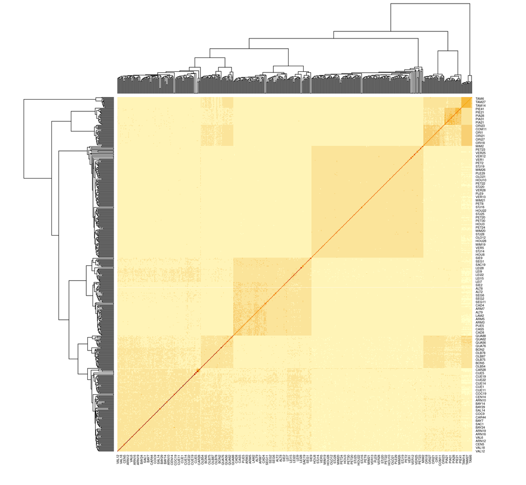

```r
heatmap(Gmat.syn)
```

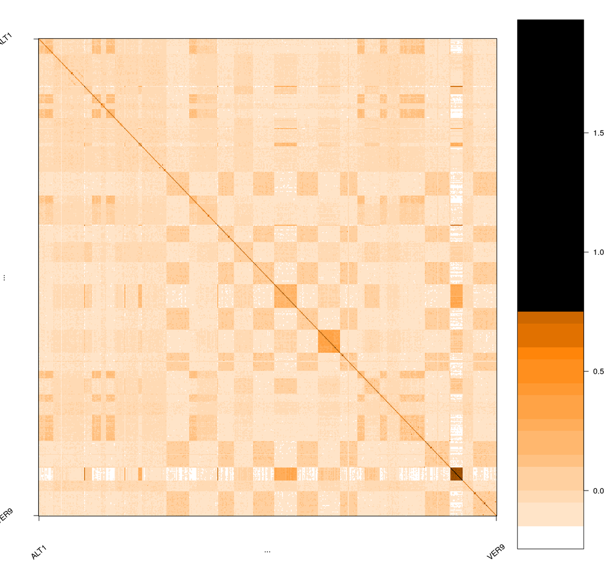

```r
plot(Gmat.syn)
```

```r
summary(Gmat.syn)
```

```
##  dimension                     523 x 523
##  rank                          522
##  range of off-diagonal values  -0.2447866 -- 1.434994
##  mean off-diagonal values      -0.002114119
##  range of diagonal values      0.5226879 -- 1.974196
##  mean diagonal values          1.10357
```

> Comparison between the matrices obtained with the package `AGHmatrix` and the one obtained with `synbreed`.

The matrix obtained with `synbreed` is nearly equall (numerically equall) to the matrix obtained with no imputation and the method of VanRaden in `AGHmatrix`. Which is reassuring! So, for me, both packages give the same results and it doesn't matter which one we use.

```r
all.equal(as.matrix(as.data.frame(Gmat.syn)),Gmat.all.a)
```

```
## [1] TRUE
```

```r
all.equal(as.matrix(as.data.frame(Gmat.syn)),Gmat.all.b)
```

```
## [1] "Mean relative difference: 0.01665923"
```

```r
all.equal(as.matrix(as.data.frame(Gmat.syn)),Gmat.all.c)
```

```
## [1] "Mean relative difference: 0.1218208"
```

## 1.3 Not positive definite matrices

Let's use the matrix from `AGHmatrix`: `Gmat.all.a`.

```r
is.symmetric.matrix(Gmat.all.a)
```

```
## [1] FALSE
```

```r
sum(eigen(Gmat.all.a)$values<0)
```

```
## [1] 1
```

**Problem:** `Gmat.all.a` is not postive definite! This is due to the numerical computation of the matrix, which sometimes give very very small eigen values instead of zeros. Here for instance Ben Bolker talks about it: https://stackoverflow.com/questions/29615440/one-of-eigenvalues-of-covariance-matrix-is-negative-in-r

I found two ways of dealing with this problem.

### 1.3.1 First option

The first option is to use buit-in functions of R, namely `forceSymetric` to force the matrix to be symmetrical and `nearPD` to find the nearest positive definite matrix. We can then check with `all.equal` if the matrices are "numerically equal" (=nearly equal).

```r
# Force the matrix to be symmetrical:
Gmat.all.a.sym <- as.matrix(forceSymmetric(Gmat.all.a))
is.symmetric.matrix(Gmat.all.a.sym) # Now, the matrix is symmetric
```

```
## [1] TRUE
```

```r
# Now, the matrix is symmetric and numerically equal to the non-symmatrical matrix:
all.equal(Gmat.all.a,Gmat.all.a.sym)
```

```
## [1] TRUE
```

```r
# Find the nearest positive definite matrix:
Gmat.all.a.pos <- as.matrix(nearPD(Gmat.all.a.sym)$mat)
is.positive.definite(Gmat.all.a.pos)
```

```
## [1] TRUE
```

```r
# Now, the matrix is positive definite and numerically equal to the non-positive definite matrix
all.equal(Gmat.all.a,Gmat.all.a.pos)
```

```
## [1] TRUE
```

This is the method which was used in the manuscript.

### 1.3.2 Second option

Following this blog post: https://aeolister.wordpress.com/2016/06/27/fixing-a-non-positive-definite-kinship-matrix/

**Method**: "increase the sum of the eigenvalues by adding a constant quantity to all terms of the diagonal. This may be sufficient to make all eigenvalues positive and consequently the kinship matrix positive definite. A good value to add: the minimum eigenvalue."

The function used is:

```r
normalize_kinmat <- function(kinmat){
  #normalize kinship so that Kij \in [0,1]
  tmp=kinmat - min(kinmat)
  tmp=tmp/max(tmp)
  tmp[1:9,1:9]
  #fix eigenvalues to positive
  diag(tmp)=diag(tmp)-min(eigen(tmp)$values)
  tmp[1:9,1:9]
  return(tmp)
}
```

```r
Gmat.all.a.fixed <- normalize_kinmat(Gmat.all.a)
is.symmetric.matrix(Gmat.all.a.fixed)
```

```
## [1] FALSE
```

```r
sum(eigen(Gmat.all.a.fixed)$values<0)
```

```
## [1] 0
```

The matrix is still not symmetrical but no longer has negative eigen values. So `brms` accepts it. But this method doesn't work every time, see the section `2.4.2` where it didn't work. So I did not use this method in the manuscript.

# 2 A GRM with only "neutral" SNPs

**This is this matrix that will be used in the manuscript.**

## 2.1 Splitting height-associated and "neutral" SNPs

In this part, we built a genomic relationship matrix (GRM) with SNPs not associated with height (GRMn).

### 2.1.1 Looking at piMASS outputs

From [piMASS manual](https://www.haplotype.org/download/pimass-manual.pdf):

For quantitative phenotypes, the file contains:

- SNP ID
- chromosome
- position
- estimates of the posterior inclusion probabilities based on simple counting (`postc`)
- **estimates of the posterior inclusion probabilities based on Rao-Blackwellization** (`postrb`)
- the naive estimates of the posterior effect size (`beta`)
- **Rao-Blackwellized estimates of the posterior effect size** (`betarb`)."

```r
beta.snp <- read_delim("../../data/piMASSoutputs/height_all_sites_res.mcmc.txt", "\t", escape_double = FALSE, trim_ws = TRUE)
```

```r
head(beta.snp)
```

```
## # A tibble: 6 x 7
##   rs         chr   pos  postc postrb    beta   betarb
##   <chr>    <dbl> <dbl>  <dbl>  <dbl>   <dbl>    <dbl>
## 1 SNP_0001     0     1 0.0702 0.0672 -0.0624 -0.00285
## 2 SNP_0002     0     2 0.0441 0.0461  0.0245  0.00072
## 3 SNP_0003     0     3 0.0656 0.0686 -0.0595 -0.00299
## 4 SNP_0004     0     4 0.0550 0.0607  0.0484  0.00207
## 5 SNP_0005     0     5 0.0697 0.0738 -0.0678 -0.00348
## 6 SNP_0006     0     6 0.121  0.144  -0.110  -0.0107
```

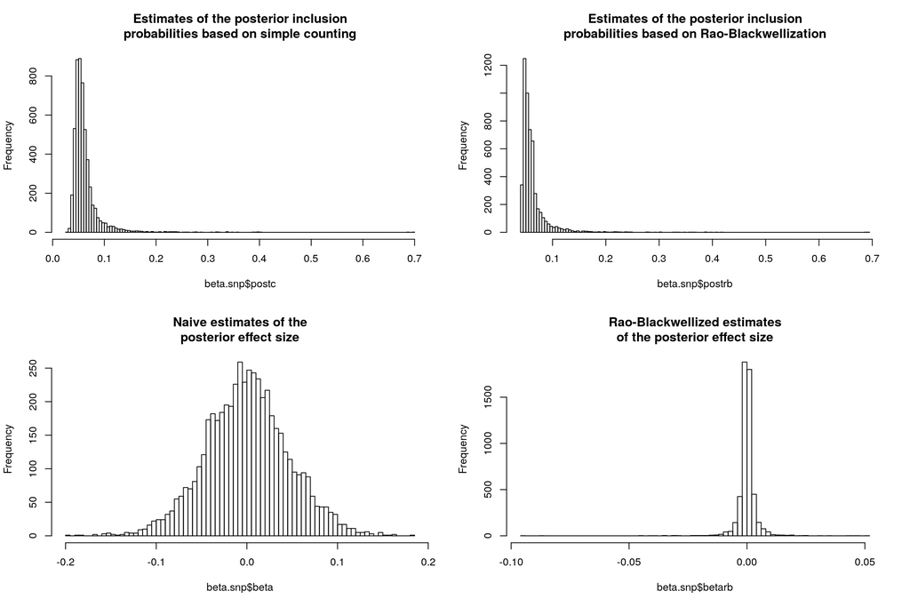

> SNPs with posterior inclusion probability (based on Rao-Blackwellization) higher than 0.1.

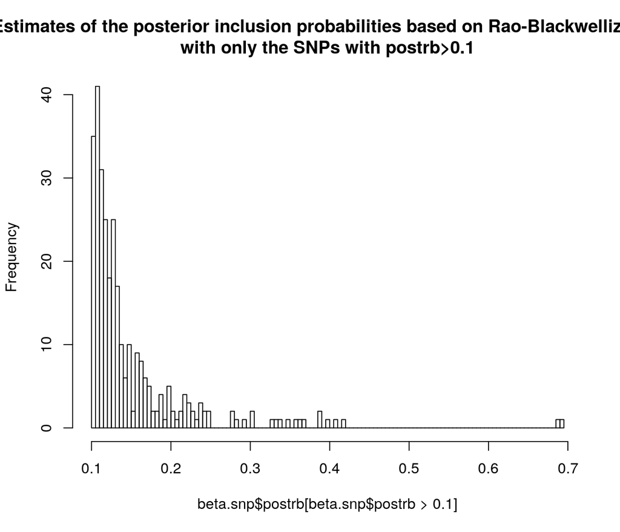

```r
hist(beta.snp$postrb[beta.snp$postrb>0.1],100L,
     main="Estimates of the posterior inclusion probabilities based on Rao-Blackwellization\nwith only the SNPs with postrb>0.1")
```

```r
beta.snp[abs(beta.snp$postrb)>0.4|abs(beta.snp$postrb)==0.4,]
```

```
## # A tibble: 4 x 7
##   rs         chr   pos postc postrb   beta  betarb
##   <chr>    <dbl> <dbl> <dbl>  <dbl>  <dbl>   <dbl>
## 1 SNP_0129     0   126 0.402  0.416  0.181  0.0516
## 2 SNP_4437     0  3653 0.697  0.686 -0.181 -0.0879
## 3 SNP_4540     0  3751 0.399  0.408  0.161  0.0471
## 4 SNP_5338     0  4454 0.689  0.691 -0.198 -0.0951
```

> Here we can see that there are two SNPs (`SNP_4437` and `SNP_5338`) with high posterior inclusion probabilities compared to the others.

> SNPs with Rao-Blackwellized estimate of the posterior effect size higher than 0.01.

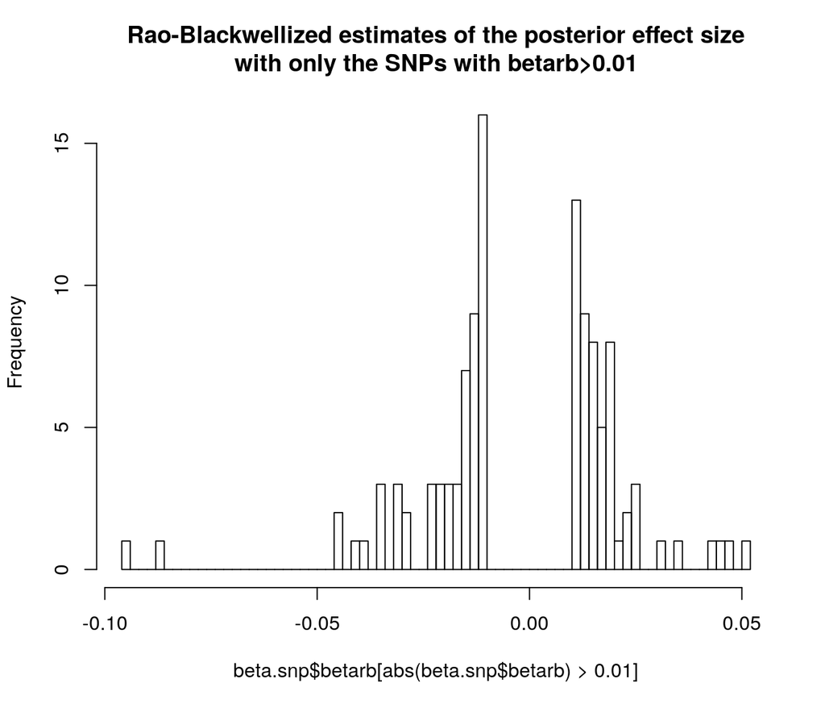

```r
hist(beta.snp$betarb[abs(beta.snp$betarb)>0.01],100L,
     main="Rao-Blackwellized estimates of the posterior effect size\nwith only the SNPs with betarb>0.01")
```

```r
beta.snp[abs(beta.snp$betarb)>0.05|abs(beta.snp$betarb)==0.05,]
```

```
## # A tibble: 3 x 7
##   rs         chr   pos postc postrb   beta  betarb
##   <chr>    <dbl> <dbl> <dbl>  <dbl>  <dbl>   <dbl>
## 1 SNP_0129     0   126 0.402  0.416  0.181  0.0516
## 2 SNP_4437     0  3653 0.697  0.686 -0.181 -0.0879
## 3 SNP_5338     0  4454 0.689  0.691 -0.198 -0.0951
```

> `SNP_4437` and `SNP_5338` also have much higher estimates of their posterior effect size compared to the others.

**COMMENT:** I was a little confused about the interpretation of piMASS outputs. For me, two SNPs were associated with height (`SNP_4437` and `SNP_5338`) and the other were likely not associated with height. `piMASS` uses the BVSR methodology and according to Zhou, Carbonetto, and Stephens (2013), "BVSR assumes that a very small proportion of variants have an effect (so we can interpret the BVSR as assuming a small number of larger effects)". This is visually shown in the following figure from [Romain Villoutreix's presentation](http://romainvilloutreix.alwaysdata.net/romainvilloutreix/wp-content/uploads/2017/01/gwas_gemma-2017-01-17.pdf). So, I was wondering if we can really consider that the SNPs with posterior inclusion probabilities lower than 0.5 and posterior estimate effect sizes lower than 0.05 are associated to height. I was really uncomfortable with the idea of arbitrarily separating SNPs between some with a slightly higher (though still very low) posterior estimate of the effect size.

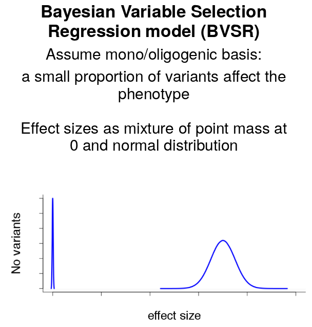

Santiago Gonzalez-Martinez's answer: "I think it is fine. What you want to select is not the markers directly associated with height (low chance for that, except perhaps the two that are clearly outstanding) but those that "have non-zero effects" on the phenotype (probably due to LD with causal -but unkown- SNPs). Taking those with higher absolute effects on the phenotype is reasonable. At the end, the exercise is reduced to compute kinship based on the genotypes that explain the phenotype, if you compute the "perfect" kinship matrix based on all the relevant genotypes, you should get the phenotype straight. But if you just used SNPs with "partial" information, you may still recover a part of the phenotype. That's exactly what we want to test, whether this is useful or not to improve your models, beyond the use of climatice data to predict heights."

Santiago Gonzalez-Martinez: "For height, we are expecting about 350 SNPs with non-zero effects, thus I would adjust the threshold to obtain around these numbers." (email 06/01/2020)

Miguel et al. (2020) showed that about 350 SNPs were associated with height in maritime pine (in a study on the same provenance trials). So we decided to find a threshold of the posterior effect size alllowing to select about 350 SNPs associated with height (at least potentially associated with height). See below.

### 2.1.2 Splitting the SNPs

We are going to use the column `betarb` (=Rao-Blackwellized estimates of the posterior effect size) to select the SNPs which will no be included in the matix of "neutral" SNPs.

No missing values in this dataset.

```r
sapply(beta.snp, function(x) sum(is.na(x)))
```

```
##     rs    chr    pos  postc postrb   beta betarb
##      0      0      0      0      0      0      0
```

```r
sapply(beta.snp, function(x) sum(x==-9))
```

```
##     rs    chr    pos  postc postrb   beta betarb
##      0      0      0      0      0      0      0
```

```r
# Threshold of 0.006
length(beta.snp$rs[abs(beta.snp$betarb)>0.006|abs(beta.snp$betarb)==0.006])
```

```
## [1] 322
```

```r
# Threshold of 0.007
length(beta.snp$rs[abs(beta.snp$betarb)>0.007|abs(beta.snp$betarb)==0.007])
```

```
## [1] 244
```

```r
# Threshold of 0.005
length(beta.snp$rs[abs(beta.snp$betarb)>0.005|abs(beta.snp$betarb)==0.005])
```

```
## [1] 435
```

> Let's take a threshold of 0.006 to select the SNPs associated to height.

```r
# Snps associated with height
snps.h <- beta.snp$rs[abs(beta.snp$betarb)>0.006|abs(beta.snp$betarb)==0.006]
length(snps.h)
```

```
## [1] 322
```

```r
# Snps not associated with height ("neutral")
snps.n <- beta.snp$rs[abs(beta.snp$betarb)<0.006]
length(snps.n)
```

```
## [1] 4843
```

With a threshold of 0.006 for the effect size, 322 SNPs are associated to height and 4,843 are not associated to height.

## 2.2 Genotypes for each SNP

Same as in section 1 (A GRM with all SNPs):

- loading files with the genotype names and the genotype of each clone for each SNP
- format the files the SNPs in rows and the genotypes in columns.

```r
# File with the genotype names (clone names)
geno_names <- read.delim2("../../data/ClonapinBlups523IndPiMASSJuly2019.txt", row.names=1)

# File with the genotype of each clone for each SNP
geno <- read.csv("../../data/5165snps523genotypesNA.txt", header=FALSE, row.names=1)
```

```r
# Removing the first two columns with allele info (A,T, G or C)
geno <- geno[,3:dim(geno)[[2]]]

# genotype name for each column
colnames(geno) <- rownames(geno_names)

rm(geno_names)
```

Let's create the file `geno.n`, with genotypes of SNPs not associated with height.

```r
geno.n <- geno[row.names(geno) %in% snps.n,]
geno.n[1:10,1:10]
```

```
##          ALT1 ALT10 ALT2 ALT3 ALT4 ALT5 ALT6 ALT8 ALT9 ARM1
## SNP_0001    1     0    0    0    0    2    0    0    0    0
## SNP_0002    1     1    0    0    2    1    1    1    2    2
## SNP_0003    2     2    1    0    1    0    2    1    1    1
## SNP_0004    1     1    0    2    0    1    0    0    1    0
## SNP_0005    0     0    1    1    1    0    0    0    0    0
## SNP_0007    1     1    2    2    2    2    1    1    2    2
## SNP_0008    0     0    0    0    0    0    0    0    0    0
## SNP_0010    1     1    0    0    0    0    0    1    1    1
## SNP_0011    0     0    0    0    0    0    0    0    0    0
## SNP_0012    0     0    0    0    0    1    0    0    0    0
```

## 2.3 Calculating the "neutral" GRM

With the package `AGHmatrix`.

```r
# replacing integers by numeric values
geno.n[,1:dim(geno.n)[[2]]] <- apply(geno.n[ , 1:dim(geno.n)[[2]]], 2, function(x) as.numeric(as.character(x)))

mat.n <- t(as.matrix(geno.n))
str(mat.n)
```

```
##  num [1:523, 1:4843] 1 0 0 0 0 2 0 0 0 0 ...
##  - attr(*, "dimnames")=List of 2
##   ..$ : chr [1:523] "ALT1" "ALT10" "ALT2" "ALT3" ...
##   ..$ : chr [1:4843] "SNP_0001" "SNP_0002" "SNP_0003" "SNP_0004" ...
```

```r
dim(mat.n)
```

```
## [1]  523 4843
```

```r
mat.n[1:14,1:14]
```

```
##       SNP_0001 SNP_0002 SNP_0003 SNP_0004 SNP_0005 SNP_0007 SNP_0008 SNP_0010 SNP_0011 SNP_0012 SNP_0013 SNP_0014 SNP_0017 SNP_0018
## ALT1         1        1        2        1        0        1        0        1        0        0        0        1        1        2
## ALT10        0        1        2        1        0        1        0        1        0        0        0        1        0        0
## ALT2         0        0        1        0        1        2        0        0        0        0        0        0        0        1
## ALT3         0        0        0        2        1        2        0        0        0        0        0        1        1        2
## ALT4         0        2        1        0        1        2        0        0        0        0        0        1        2        2
## ALT5         2        1        0        1        0        2        0        0        0        1        0        1        0        2
## ALT6         0        1        2        0        0        1        0        0        0        0        0        1        1        1
## ALT8         0        1        1        0        0        1        0        1        0        0        0        0        2        1
## ALT9         0        2        1        1        0        2        0        1        0        0        0        1        1        2
## ARM1         0        2        1        0        0        2        0        1        0        0        0        1        2        2
## ARM10        1        2        1        1        0        2        0        0        0        0        0        1        1        2
## ARM3         0        2        0        0        0        2        0        0        0        0        0        1        0        1
## ARM4         0        2        2        1        0        2        0        0        0        0        0        2        2        1
## ARM5         1        1        1        1        0        2        0        0        0        0        0        2        1        1
```

```r
Gmatrix.n <- Gmatrix(mat.n,method="VanRaden", missingValue = NA, verify.posdef=T)
```

```
## Initial data:
##  Number of Individuals: 523
##  Number of Markers: 4843
##
## Missing data check:
##  Total SNPs: 4843
##   0 SNPs dropped due to missing data threshold of 1
##  Total of: 4843  SNPs
## MAF check:
##  No SNPs with MAF below 0
## Monomorphic check:
##  No monomorphic SNPs
## Summary check:
##  Initial:  4843 SNPs
##  Final:  4843  SNPs ( 0  SNPs removed)
##
##   Matrix is NOT positive definite. It has  1  eigenvalues <= 0
##
## Completed! Time = 1.036  seconds
```

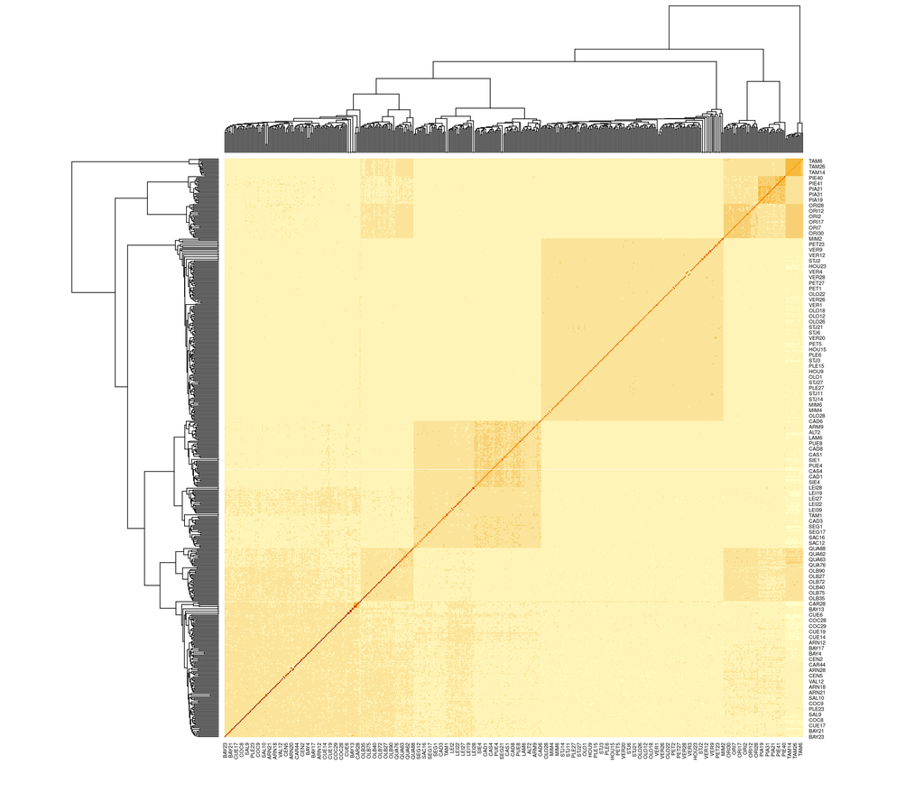

```r
heatmap(Gmatrix.n)
```

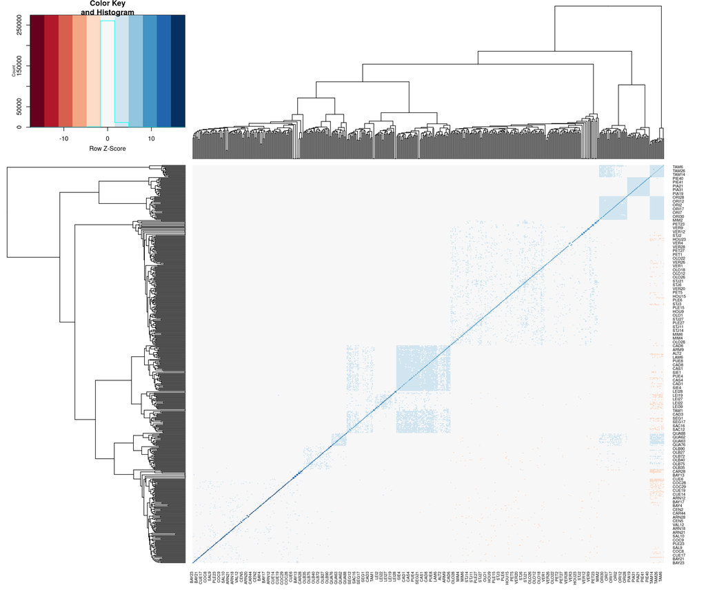

```r
heatmap.2(as.matrix(Gmatrix.n),scale="row",col=brewer.pal(11,"RdBu"),trace="none")
```

## 2.4 Positive definite GRM

Problem: `Gmatrix.n` is not positive definite.

```r
sum(eigen(Gmatrix.n)$values<0)
```

```
## [1] 1
```

```r
eigen(Gmatrix.n)$values[eigen(Gmatrix.n)$values<0]
```

```
## [1] -3.313225e-15
```

### 2.4.1 First option

First, the matrix is not symmetrical, so let's correct that.

```r
# GRMn
is.symmetric.matrix(Gmatrix.n)
```

```
## [1] FALSE
```

```r
Gmatrix.n.sym <- as.matrix(forceSymmetric(Gmatrix.n))
is.symmetric.matrix(Gmatrix.n.sym)
```

```
## [1] TRUE
```

```r
# The symmetric GRM and the non-symmetric matrices are "nearly equal".
all.equal(Gmatrix.n,Gmatrix.n.sym)
```

```
## [1] TRUE
```

But the negative eigne values are still there. Need to make the matrix positive definite (to do then the cholesky decomposition in the model.).

```r
sum(eigen(Gmatrix.n.sym)$values<0)
```

```
## [1] 1
```

```r
eigen(Gmatrix.n.sym)$values[eigen(Gmatrix.n.sym)$values<0]
```

```
## [1] -3.270455e-15
```

```r
is.positive.definite(Gmatrix.n.sym)
```

```
## [1] FALSE
```

```r
Gmatrix.n.pos <- as.matrix(nearPD(Gmatrix.n)$mat)
is.positive.definite(Gmatrix.n.pos)
```

```
## [1] TRUE
```

```r
all.equal(Gmatrix.n,Gmatrix.n.pos)
```

```
## [1] TRUE
```

`Gmatrix.n` and `Gmatrix.n.pos` are nearly equal.

Let's save the matrix

```r
# saveRDS(Gmatrix.n.pos, file="../../data/GRMs/GRMVanRaden.RDS")
```

### 2.4.2 Second option

See description second option here

```r
Gmat.n.alves <- normalize_kinmat(Gmatrix.n.sym)
is.symmetric.matrix(Gmat.n.alves)
```

```
## [1] TRUE
```

```r
is.positive.definite(Gmat.n.alves)
```

```
## [1] FALSE
```

```r
sum(eigen(Gmat.n.alves)$values<0)
```

```
## [1] 1
```

# 3 Comparing GRM with all SNPs and "neutral" GRM

```r
Gmat.all.a.pos[1:5,1:5]
```

```
##            ALT1     ALT10      ALT2      ALT3      ALT4
## ALT1  1.0681343 0.1121508 0.2226041 0.2148338 0.2123356
## ALT10 0.1121508 0.9298933 0.1202335 0.1245151 0.1222406
## ALT2  0.2226041 0.1202335 0.9795997 0.2013325 0.1737106
## ALT3  0.2148338 0.1245151 0.2013325 1.0139689 0.1982365
## ALT4  0.2123356 0.1222406 0.1737106 0.1982365 0.9743793
```

```r
Gmatrix.n.pos[1:5,1:5]
```

```
##            ALT1     ALT10      ALT2      ALT3      ALT4
## ALT1  1.0782559 0.1187100 0.2322634 0.2199000 0.2167321
## ALT10 0.1187100 0.9340635 0.1224585 0.1231115 0.1164435
## ALT2  0.2322634 0.1224585 0.9817821 0.2119465 0.1701029
## ALT3  0.2199000 0.1231115 0.2119465 1.0153464 0.2094680
## ALT4  0.2167321 0.1164435 0.1701029 0.2094680 0.9820160
```

```r
all.equal(Gmat.all.a.pos,Gmatrix.n.pos)
```

```
## [1] "Mean relative difference: 0.06191964"
```

# References

Guan, Yongtao, and Matthew Stephens. 2011. “Bayesian Variable Selection Regression for Genome-Wide Association Studies and Other Large-Scale Problems.” *The Annals of Applied Statistics* 5 (3): 1780–1815. doi:10.1214/11-AOAS455.

Miguel, Marina de, Isabel Rodríguez-Quilón, Myriam Heuertz, Agathe Hurel, Delphine Grivet, Juan-Pablo Jaramillo-Correa, Giovanni G. Vendramin, et al. 2020. “Polygenic Adaptation and Negative Selection Across Traits, Years and Environments in a Long-Lived Plant Species (Pinus Pinaster Ait.).” *bioRxiv*, March. Cold Spring Harbor Laboratory, 2020.03.02.974113. doi:10.1101/2020.03.02.974113.

Zhou, Xiang, Peter Carbonetto, and Matthew Stephens. 2013. “Polygenic Modeling with Bayesian Sparse Linear Mixed Models.” *PLoS Genetics* 9 (2). Public Library of Science.